# HW5

Brandon Xicon:xiconb

4/8/2020

*Note that reading data and loading packages is hidden on the HTML for readabilty*

## Liquor Sales in Iowa

This dataset https://data.iowa.gov/Sales-Distribution/2019-Iowa-Liquor-Sales/38x4-vs5h contains the spirits purchase information of Iowa Class “E” liquor licensees by product and date of purchase for 2019. The dataset can be used to analyze total spirits sales in Iowa of individual products at the store level.

**Submission instructions**: Create a folder named `ds202_hw5`, and name the RMarkDown file including your solutions `hw5.Rmd` under this folder. For the submission, create a GitHub repository named `ds202_hw5` under your GitHub account, and push both `hw5.Rmd` and the knitted `hw5.html` before the deadline. I will assume you use the same GitHub username as for your HW4 submission. The latest version of your homework appearing on GitHub before the deadline is graded. *It is crucial to follow the exact folder structure and file names*, so that your homework can be reproduced and graded by an automated script. This homework is **due on April 10** by 11:59 pm.

1. The complete dataset is too large. Download and import the alcohol sales data for Ames only:
1. Go to https://data.iowa.gov/Sales-Distribution/2019-Iowa-Liquor-Sales/38x4-vs5h
2. Click Filter – Filter – Go advanced now
3. Add a New Filter Condition: City is Ames.
4. Export – CSV – Download
5. Use `readr::read_csv` to import.
2. Data cleaning:
1. extract geographic latitude and longitude from the variable `Store Location`
2. make sure the variables are in the correct type, by converting incorrect variable types.
3. extract year, month and day from the variable `Date` as separate columns.

```r
#Getting longitude and latitude from Store Location
Liquor <- Liquor %>%
  na.omit %>%
  mutate(`Store Location`=substr(`Store Location`, 8, nchar(`Store Location`) - 1)) %>%
  separate(col='Store Location', into=c('Latitude', 'Longitude'), sep=" ")

#changing values to numeric

Liquor<-Liquor %>%
  mutate(Latitude = as.numeric(Latitude)) %>%
  mutate(Longitude = as.numeric(Longitude)) %>%
  mutate(`Vendor Number` = as.numeric(`Vendor Number`))

#Getting day month year from date as seperate columns

Liquor <- Liquor %>%
  separate('Date', c('Month', 'Day', 'Year'), sep='/') %>%
  mutate(Month = as.numeric(Month)) %>%
  mutate(Day = as.numeric(Day)) %>%
  mutate(Year = as.numeric(Year))
Liquor
```

```
## # A tibble: 48,175 x 27
##    `Invoice/Item N~ Month   Day  Year `Store Number` `Store Name` Address City
##    <chr>            <dbl> <dbl> <dbl>          <dbl> <chr>        <chr>   <chr>
##  1 INV-16835000019      1     9  2019           4509 AJ'S LIQUOR~ 2515 C~ Ames
##  2 INV-16886300007      1    11  2019           5187 Kwik Stop L~ 125 6t~ Ames
##  3 INV-17377700173      2     6  2019           4129 Cyclone Liq~ 626 Li~ Ames
##  4 INV-17376600028      2     6  2019           3973 MMDG SPIRIT~ 126A W~ Ames
##  5 INV-17377300189      2     6  2019           2501 Hy-Vee  #2 ~ 640 Li~ Ames
##  6 INV-17524000103      2    13  2019           4129 Cyclone Liq~ 626 Li~ Ames
##  7 INV-17523900006      2    13  2019           4129 Cyclone Liq~ 626 Li~ Ames
##  8 INV-17524000110      2    13  2019           4129 Cyclone Liq~ 626 Li~ Ames
##  9 INV-17523600051      2    13  2019           2501 Hy-Vee  #2 ~ 640 Li~ Ames
## 10 INV-17807600087      2    27  2019           2501 Hy-Vee  #2 ~ 640 Li~ Ames
## # ... with 48,165 more rows, and 19 more variables: `Zip Code` <dbl>,
## #   Latitude <dbl>, Longitude <dbl>, `County Number` <dbl>, County <chr>,
## #   Category <dbl>, `Category Name` <chr>, `Vendor Number` <dbl>, `Vendor
## #   Name` <chr>, `Item Number` <dbl>, `Item Description` <chr>, Pack <dbl>,
## #   `Bottle Volume (ml)` <dbl>, `State Bottle Cost` <dbl>, `State Bottle
## #   Retail` <dbl>, `Bottles Sold` <dbl>, `Sale (Dollars)` <dbl>, `Volume Sold
## #   (Liters)` <dbl>, `Volume Sold (Gallons)` <dbl>
```

3. First overview:
1. Plot a scatterplot of lat and long of store locations.

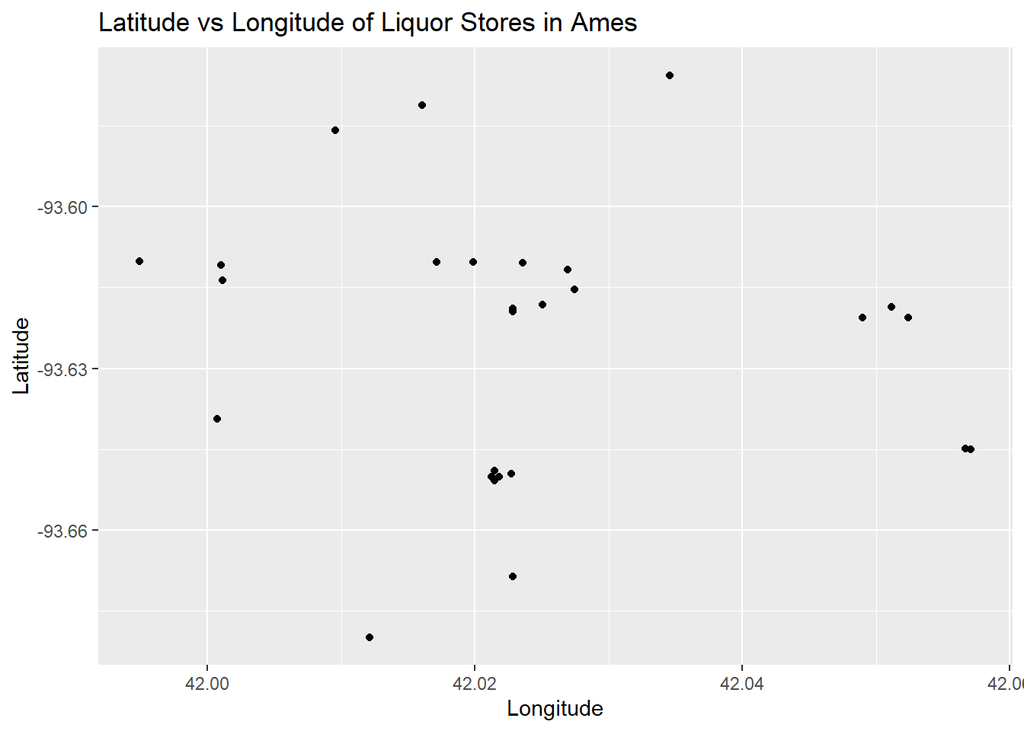

```r
Liquor %>% ggplot(aes(x=Longitude, y=Latitude)) + geom_point() +
  ggtitle("Latitude vs Longitude of Liquor Stores in Ames")
```

b. Provide a visual breakdown of the liquor category (by `Category Name`). Include volume sold in the breakdown.

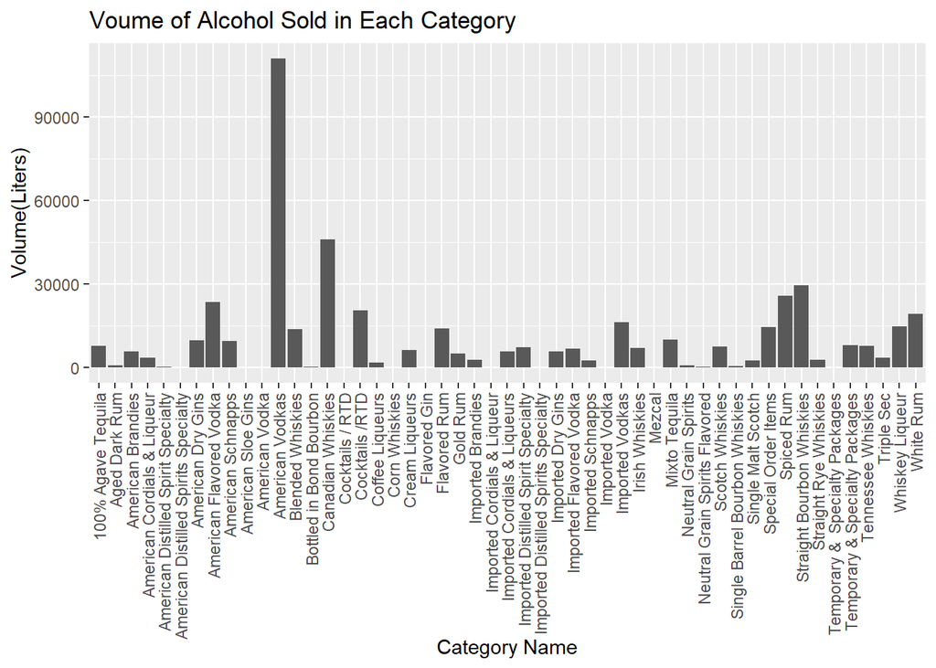

```r
#ggplot(Liquor,aes(x=`Category Name`, count=`Volume Sold (Liters)`)) +
 # geom_bar(position=position_dodge(width = .5)) +
  #ylab('Volume Sold (Liters)') +
  #ggtitle("Voume of Alcohol Sold in Each Category")+theme(axis.text.x=element_text(angle=90,hjust=1,vjust=0.5))
Liquor %>%
  filter(!is.na(`Category Name`)) %>%
  group_by(`Category Name`) %>%
  summarize(`Volume(Liters)` = sum(`Volume Sold (Liters)`)) %>%
  ggplot(aes(x = `Category Name`, y = `Volume(Liters)`)) +
  geom_bar(stat = "identity") +
ggtitle("Voume of Alcohol Sold in Each Category")+theme(axis.text.x=element_text(angle=90,hjust=1,vjust=0.5))
```

4. Find the daily sales liquor sales in Ames in 2019. Summarize the number of sales, volume of liquor sold, and amount of money spent.

```r
Liquor2<-Liquor %>%
  group_by(Month, Day,Year) %>%
  summarize(`Number of Sales` = n(), `Total Volume Sold (Liters)` = sum(`Volume Sold (Liters)`),
            `Money Spent` = sum(`Sale (Dollars)`)) %>%
  arrange(Month,Day,Year,desc(`Number of Sales`))
Liquor2
```

```
## # A tibble: 146 x 6
## # Groups:   Month, Day [146]
##    Month   Day  Year `Number of Sales` `Total Volume Sold (Liters~ `Money Spent`
##    <dbl> <dbl> <dbl>             <int>                       <dbl>         <dbl>
##  1     1     3  2019               767                       4944.        83304.
##  2     1     4  2019               143                       1256.        16766.
##  3     1     9  2019               701                       5616.        82540.
##  4     1    10  2019                 2                        135          1457.
##  5     1    11  2019               153                       1038.        14427.
##  6     1    16  2019               632                       6748.        95180.
##  7     1    24  2019               900                       7167.       105730.
##  8     1    25  2019               253                       2329.        31893.
##  9     1    30  2019               795                       7132.       103468.
## 10     1    31  2019                18                        154.         2223
## # ... with 136 more rows
```

5. Plot volume sold by day (use a scatterplot of volume by day and facet by month). Discover trends with the help of `geom_smooth`. Describe any patterns.

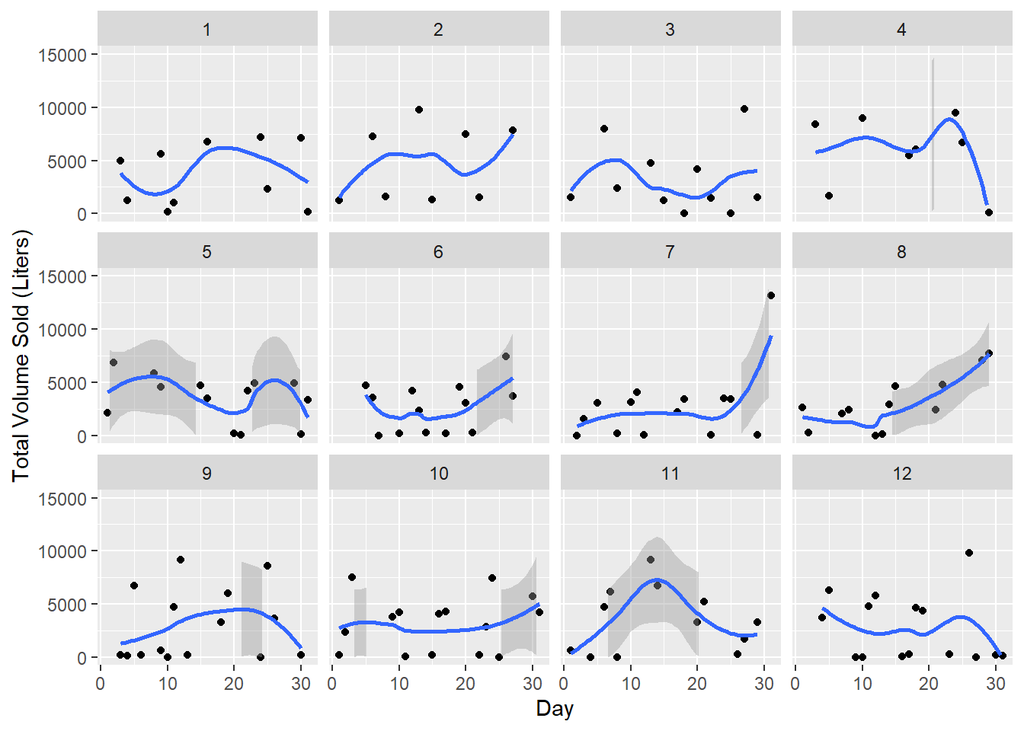

```r
ggplot(Liquor2,aes(x=Day,y=`Total Volume Sold (Liters)`))+facet_wrap(. ~Month)+geom_point()+geom_smooth()+
  ylim(0, 15000)
```

6. Find the dates for ISU football home games in Fall 2019. Can you see a pattern? ` home games were 8/31,9/14,9/21,10/5,10/26,11/16,11/23 These points do not exist in our dataframe however based on the best fit lines above we see that the spikes or high points in each month seemed to correspond to the home games.

Note: your submission is supposed to be fully reproducible, i.e. the TA and I will ‘knit’ your submission in RStudio.